# Trilha3-Explorando a Base de Dados diamonds do pacote ggplot2

André Gustavo Silva Lovo

07/11/2020

# Trilha3

```r
#install.packages("readr", dependencies = TRUE)
library(readr)
#install.packages("data.table", dependencies = TRUE)
#library(data.table)
#install.packages("knitr", dependencies = TRUE)
library(knitr)
#install.packages("tinytex")
#tinytex::install_tinytex()
#install.packages("ggplot2", dependencies = TRUE)
#install.packages("dplyr", dependencies = TRUE)
library(dplyr)
#install.packages("tidyr", dependencies = TRUE)
library(tidyr)
```

## Para esta atividade de AED (Análise Exploratória de Dados) vamos seguir o seguinte checklist:

[figure not shown]

ckecklist

```r
library(ggplot2)
diamantes <- data(diamonds)
```

# Dados e informações do Banco de dados diamonds:

price: preço em dólares americanos ($326–$18,823)  
carat: peso do diamente (0.2–5.01)  
cut:qualidade do corte (Fair, Good, Very Good, Premium, Ideal)  
color: cor do diamante, indo de J (pior) a D (melhor)  
clarity: medida de quão claro é o diamante (I1 (pior), SI2, SI1, VS2, VS1, VVS2, VVS1, IF (melhor))  
x: comprimento em mm (0–10.74)  
y: largura em mm (0–58.9)  
z: profundidade em mm (0–31.8)  
depth: percentual de profundidade total = z / mean(x, y) = 2 * z / (x + y) (43–79)  
table: largura do topo do diamante relativo ao ponto mais largo (43–95)

Como pode ser observado a tabela apresenta as seguintes variáveis para a quantificação e qualificação de uma tabela com características para os diamantes:  
Preço - peso - qualidade do corte - claridade - comprimento - largura - profundidade - profundidade total em porcentagem - relação de largura entre o topo e a parte mais larga.

```r
dim(diamonds)
```

```
## [1] 53940    10
```

## Investigando e analisando a base de dados:

### Qual é a estrutura do conjunto de dados “diamantes”?

```r
View (diamonds)
```

```r
typeof(diamonds$price)
```

```
## [1] "integer"
```

```r
typeof(diamonds$carat)
```

```
## [1] "double"
```

```r
typeof(diamonds$cut)
```

```
## [1] "integer"
```

```r
typeof(diamonds$color)
```

```
## [1] "integer"
```

```r
typeof(diamonds$clarity)
```

```
## [1] "integer"
```

```r
typeof(diamonds$depth)
```

```
## [1] "double"
```

```r
typeof(diamonds$table)
```

```
## [1] "double"
```

```r
typeof(diamonds$x)
```

```
## [1] "double"
```

```r
typeof(diamonds$y)
```

```
## [1] "double"
```

```r
typeof(diamonds$z)
```

```
## [1] "double"
```

```r
str(diamonds)
```

```
## tibble [53,940 x 10] (S3: tbl_df/tbl/data.frame)
##  $ carat  : num [1:53940] 0.23 0.21 0.23 0.29 0.31 0.24 0.24 0.26 0.22 0.23 ...
##  $ cut    : Ord.factor w/ 5 levels "Fair"<"Good"<..: 5 4 2 4 2 3 3 3 1 3 ...
##  $ color  : Ord.factor w/ 7 levels "D"<"E"<"F"<"G"<..: 2 2 2 6 7 7 6 5 2 5 ...
##  $ clarity: Ord.factor w/ 8 levels "I1"<"SI2"<"SI1"<..: 2 3 5 4 2 6 7 3 4 5 ...
##  $ depth  : num [1:53940] 61.5 59.8 56.9 62.4 63.3 62.8 62.3 61.9 65.1 59.4 ...
##  $ table  : num [1:53940] 55 61 65 58 58 57 57 55 61 61 ...
##  $ price  : int [1:53940] 326 326 327 334 335 336 336 337 337 338 ...
##  $ x      : num [1:53940] 3.95 3.89 4.05 4.2 4.34 3.94 3.95 4.07 3.87 4 ...
##  $ y      : num [1:53940] 3.98 3.84 4.07 4.23 4.35 3.96 3.98 4.11 3.78 4.05 ...
##  $ z      : num [1:53940] 2.43 2.31 2.31 2.63 2.75 2.48 2.47 2.53 2.49 2.39 ...
```

```r
View(diamonds)
```

### Explore a parte inicial e a final do conjunto de dados.

```r
head(diamonds,5)
```

```
## # A tibble: 5 x 10
##   carat cut     color clarity depth table price     x     y     z
##   <dbl> <ord>   <ord> <ord>   <dbl> <dbl> <int> <dbl> <dbl> <dbl>
## 1 0.23  Ideal   E     SI2      61.5    55   326  3.95  3.98  2.43
## 2 0.21  Premium E     SI1      59.8    61   326  3.89  3.84  2.31
## 3 0.23  Good    E     VS1      56.9    65   327  4.05  4.07  2.31
## 4 0.290 Premium I     VS2      62.4    58   334  4.2   4.23  2.63
## 5 0.31  Good    J     SI2      63.3    58   335  4.34  4.35  2.75
```

```r
tail(diamonds,10)
```

```
## # A tibble: 10 x 10
##    carat cut       color clarity depth table price     x     y     z
##    <dbl> <ord>     <ord> <ord>   <dbl> <dbl> <int> <dbl> <dbl> <dbl>
##  1  0.71 Premium   E     SI1      60.5    55  2756  5.79  5.74  3.49
##  2  0.71 Premium   F     SI1      59.8    62  2756  5.74  5.73  3.43
##  3  0.7  Very Good E     VS2      60.5    59  2757  5.71  5.76  3.47
##  4  0.7  Very Good E     VS2      61.2    59  2757  5.69  5.72  3.49
##  5  0.72 Premium   D     SI1      62.7    59  2757  5.69  5.73  3.58
##  6  0.72 Ideal     D     SI1      60.8    57  2757  5.75  5.76  3.5
##  7  0.72 Good      D     SI1      63.1    55  2757  5.69  5.75  3.61
##  8  0.7  Very Good D     SI1      62.8    60  2757  5.66  5.68  3.56
##  9  0.86 Premium   H     SI2      61      58  2757  6.15  6.12  3.74
## 10  0.75 Ideal     D     SI2      62.2    55  2757  5.83  5.87  3.64
```

### Faça alguns sumários estatísticos para entender melhor a base de dados.

```r
summary(diamonds)
```

```
##      carat               cut        color        clarity          depth
##  Min.   :0.2000   Fair     : 1610   D: 6775   SI1    :13065   Min.   :43.00
##  1st Qu.:0.4000   Good     : 4906   E: 9797   VS2    :12258   1st Qu.:61.00
##  Median :0.7000   Very Good:12082   F: 9542   SI2    : 9194   Median :61.80
##  Mean   :0.7979   Premium  :13791   G:11292   VS1    : 8171   Mean   :61.75
##  3rd Qu.:1.0400   Ideal    :21551   H: 8304   VVS2   : 5066   3rd Qu.:62.50
##  Max.   :5.0100                     I: 5422   VVS1   : 3655   Max.   :79.00
##                                     J: 2808   (Other): 2531
##      table           price             x                y
##  Min.   :43.00   Min.   :  326   Min.   : 0.000   Min.   : 0.000
##  1st Qu.:56.00   1st Qu.:  950   1st Qu.: 4.710   1st Qu.: 4.720
##  Median :57.00   Median : 2401   Median : 5.700   Median : 5.710
##  Mean   :57.46   Mean   : 3933   Mean   : 5.731   Mean   : 5.735
##  3rd Qu.:59.00   3rd Qu.: 5324   3rd Qu.: 6.540   3rd Qu.: 6.540
##  Max.   :95.00   Max.   :18823   Max.   :10.740   Max.   :58.900
##
##        z
##  Min.   : 0.000
##  1st Qu.: 2.910
##  Median : 3.530
##  Mean   : 3.539
##  3rd Qu.: 4.040
##  Max.   :31.800
##
```

## Analisando a tabela e suas colunas:

Coluna price: preço em dólares americanos-  
R:(Atributo tipo numérico inteiro)  
Coluna carat: peso do diamente-  
R:(Atributo tipo numérico double com casas decemais)  
Coluna cut:qualidade do corte (Fair, Good, Very Good, Premium, Ideal)-  
R:(Atributo tipo Factor - categórico ou qualitativo)  
Coluna color: cor do diamante, indo de J (pior) a D (melhor)-  
R:(Atributo tipo Factor - categórico ou qualitativo)  
Coluna clarity: medida de quão claro é o diamante-  
R:(Atributo tipo Factor - categórico ou qualitativo)  
Coluna depth: percentual de profundidade total-  
R:(Atributo tipo numérico double com casas decemais)  
Coluna table: largura do topo do diamante relativo ao ponto mais largo-  
R:(Atributo tipo numérico double com casas decemais)  
Coluna x: comprimento em mm-  
R:(Atributo tipo numérico double com casas decemais)  
Coluna y: largura em mm-  
R:(Atributo tipo numérico double com casas decemais)  
Coluna z: profundidade em mm-  
R:(Atributo tipo numérico double com casas decemais)

### A saída da função summary() está de acordo com a descrição mostrada anteriormente?

As colunas que são do tipo numéricos (inteiros e/ou double com casas decimais) e seus resultados estão de acordo com a função summary ,pois apresntam tipos numéricos. Ex.:carat, price, depth, table, x,y,z.  
Já as colunas que são do tipo caracteres (factor ordinais - são do tipo categórico), não estão de acordo com a função summary.  
Ex.:cut, color, clarity.

## Resumo do Banco de Dados

Usamos esta biblioteca para visualizarmos de forma global a tabela e suas colunas(variáveis).

```r
#install.packages("skimr")
library(skimr)
skim(diamonds)
```

Data summary

| Name | diamonds |
| --- | --- |
| Number of rows | 53940 |
| Number of columns | 10 |
| _______________________ |  |
| Column type frequency: |  |
| factor | 3 |
| numeric | 7 |
| ________________________ |  |
| Group variables | None |

**Variable type: factor**

| skim_variable | n_missing | complete_rate | ordered | n_unique | top_counts |
| --- | --- | --- | --- | --- | --- |
| cut | 0 | 1 | TRUE | 5 | Ide: 21551, Pre: 13791, Ver: 12082, Goo: 4906 |
| color | 0 | 1 | TRUE | 7 | G: 11292, E: 9797, F: 9542, H: 8304 |
| clarity | 0 | 1 | TRUE | 8 | SI1: 13065, VS2: 12258, SI2: 9194, VS1: 8171 |

**Variable type: numeric**

| skim_variable | n_missing | complete_rate | mean | sd | p0 | p25 | p50 | p75 | p100 | hist |
| --- | --- | --- | --- | --- | --- | --- | --- | --- | --- | --- |
| carat | 0 | 1 | 0.80 | 0.47 | 0.2 | 0.40 | 0.70 | 1.04 | 5.01 | ▇▂▁▁▁ |
| depth | 0 | 1 | 61.75 | 1.43 | 43.0 | 61.00 | 61.80 | 62.50 | 79.00 | ▁▁▇▁▁ |
| table | 0 | 1 | 57.46 | 2.23 | 43.0 | 56.00 | 57.00 | 59.00 | 95.00 | ▁▇▁▁▁ |
| price | 0 | 1 | 3932.80 | 3989.44 | 326.0 | 950.00 | 2401.00 | 5324.25 | 18823.00 | ▇▂▁▁▁ |
| x | 0 | 1 | 5.73 | 1.12 | 0.0 | 4.71 | 5.70 | 6.54 | 10.74 | ▁▁▇▃▁ |
| y | 0 | 1 | 5.73 | 1.14 | 0.0 | 4.72 | 5.71 | 6.54 | 58.90 | ▇▁▁▁▁ |
| z | 0 | 1 | 3.54 | 0.71 | 0.0 | 2.91 | 3.53 | 4.04 | 31.80 | ▇▁▁▁▁ |

```r
#O comando skim é interessante, porque além do sumário numérico, também temos um pequeno histograma para vermos a distribuição dos dados.
# Vamos analisar as variáveis contínuas (numéricas) através dos histogramas.
```

## Gráfico Histograma

### Explorando a variável carat, através do histograma.

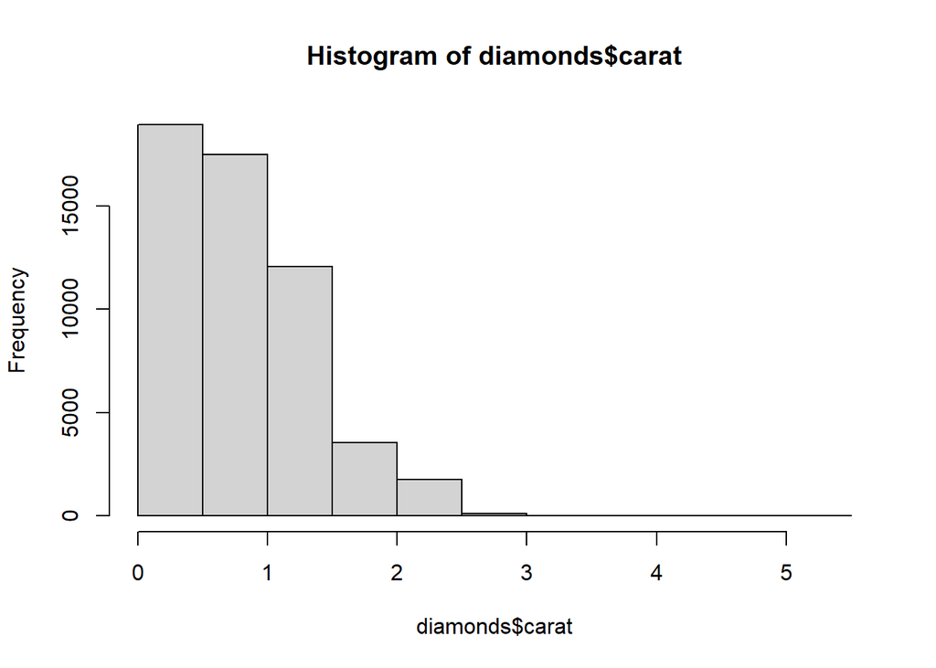

```r
hist(diamonds$carat)
```

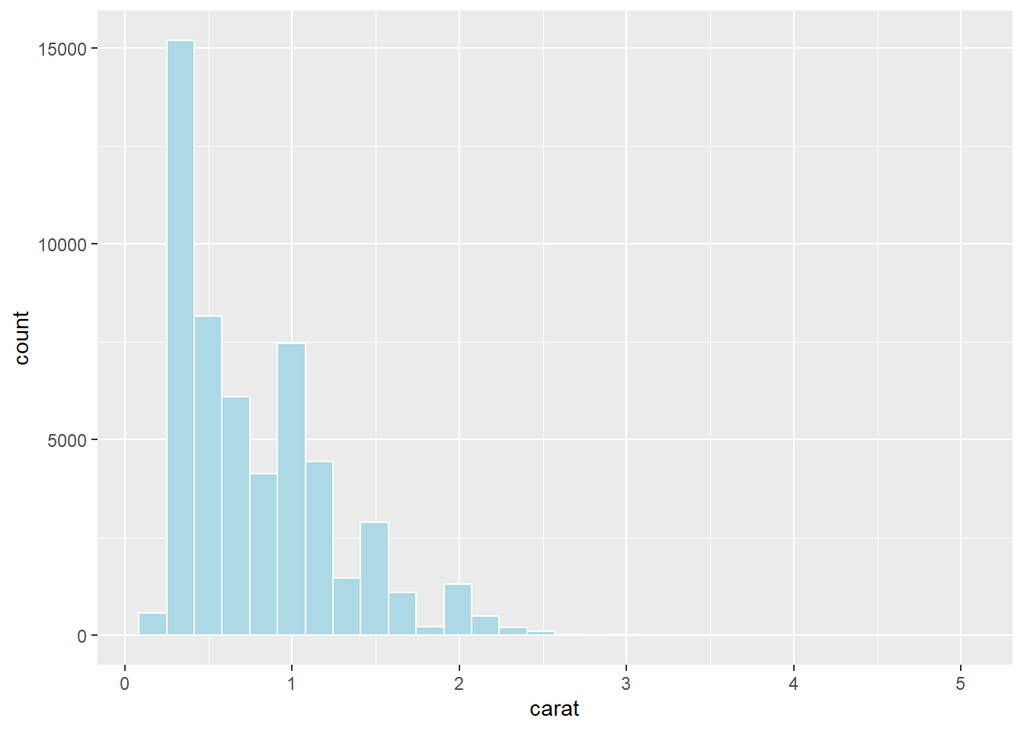

```r
ggplot(diamonds, aes(x = carat)) + geom_histogram(bins=30, color = "white", fill = "lightblue")
```

### Análise: Acima fizemos a comparação da distribuição dos pesos dos diamantes conforme a faixa das quantidades, usando o histograma.

### Explorando a variável depth, através do histograma.

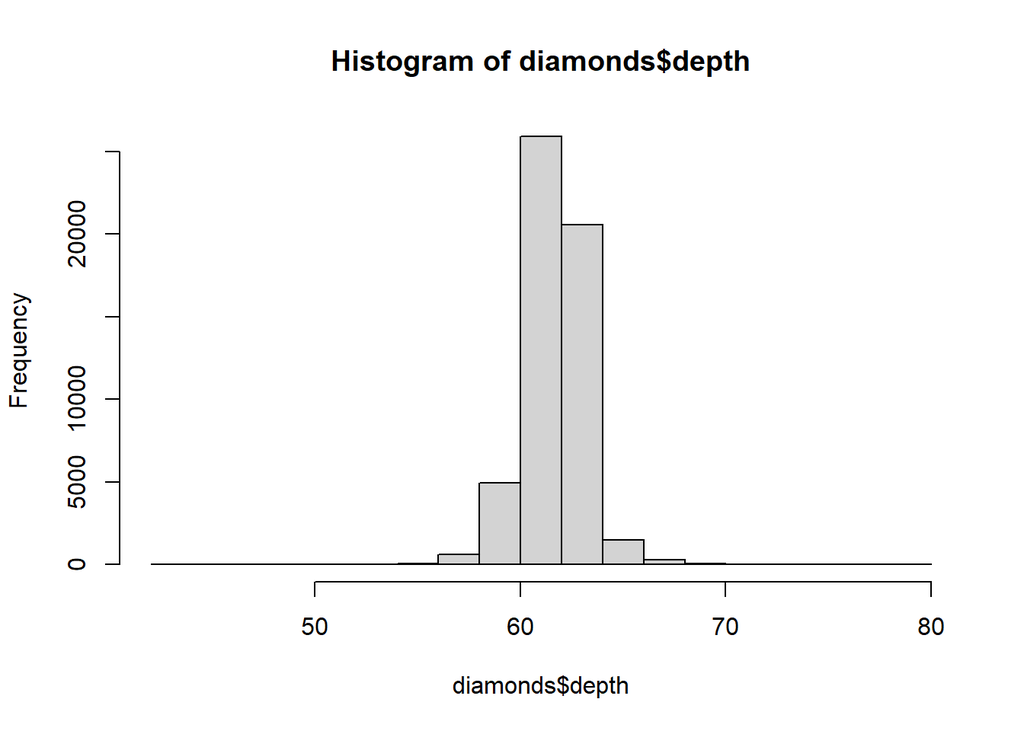

```r
hist(diamonds$depth)
```

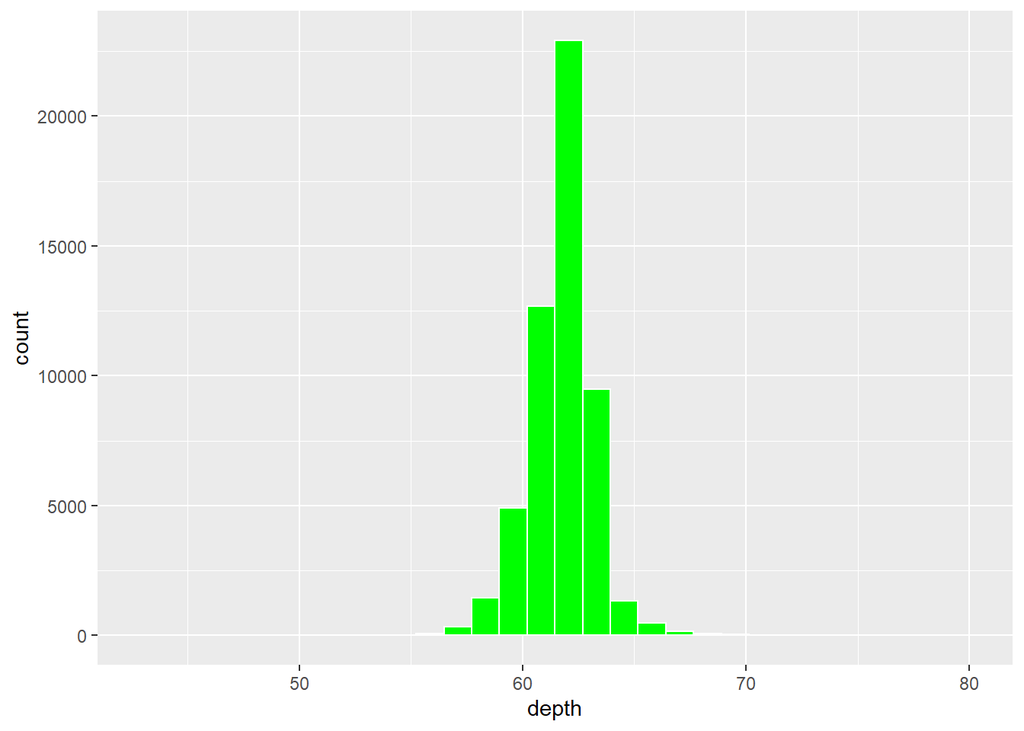

```r
ggplot(diamonds, aes(x = depth)) + geom_histogram(bins=30, color = "white", fill = "green")
```

### Análise: Acima fizemos a comparação da distribuição das profundidades (em porcentagem) dos diamantes conforme a faixa das quantidades, usando o histograma.

### Explorando a variável table, através do histograma.

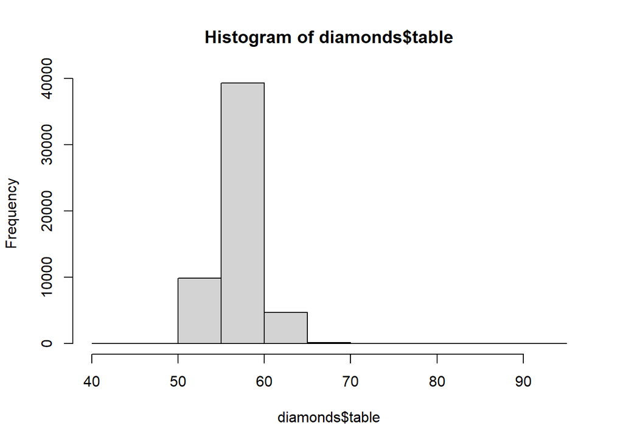

```r
hist(diamonds$table)
```

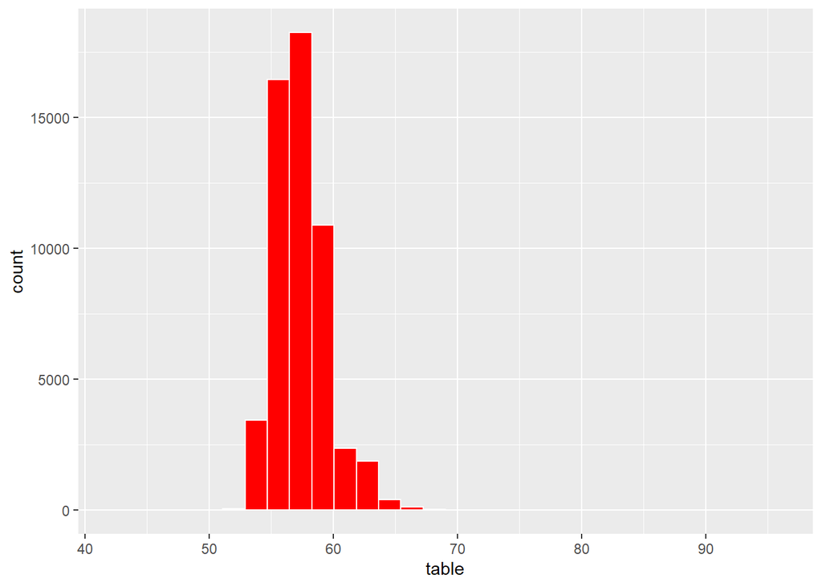

```r
ggplot(diamonds, aes(x = table)) + geom_histogram(bins = 30, color = "white", fill = "red")
```

### Explorando a variável price, através do histograma.

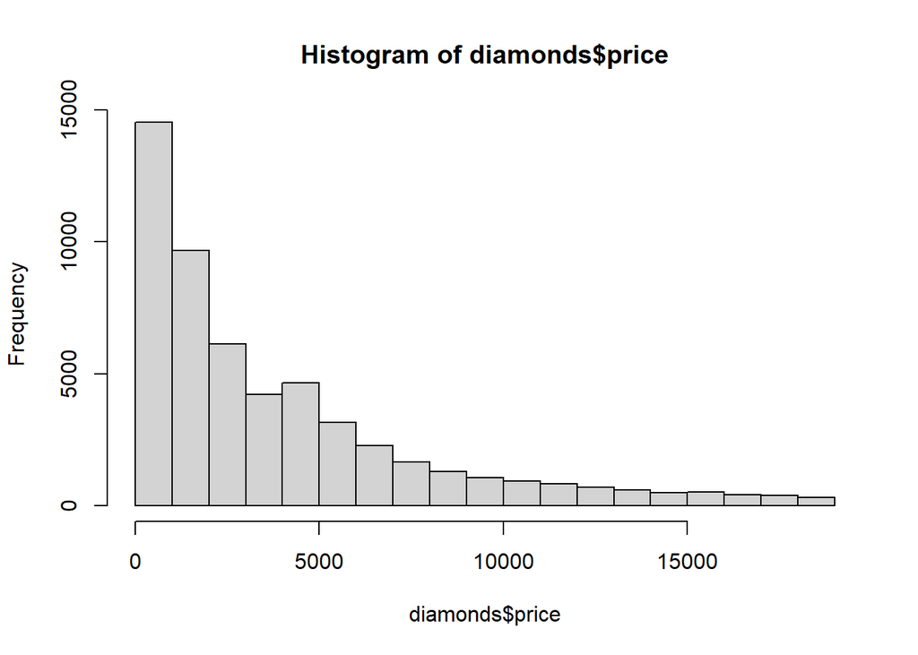

```r
hist(diamonds$price)
```

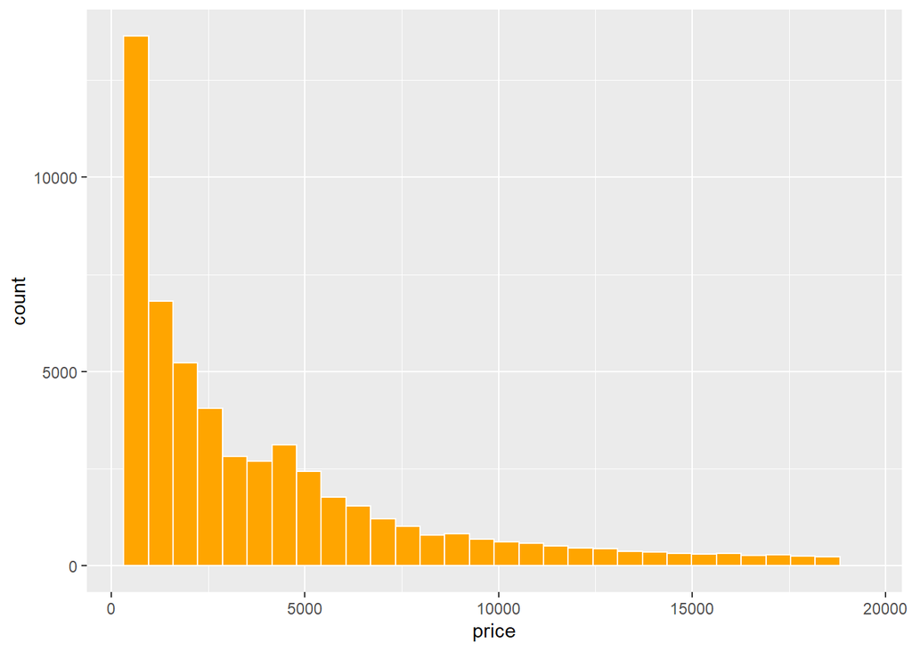

```r
ggplot(diamonds, aes(x = price)) + geom_histogram(bins = 30, color = "white", fill = "orange")
```

### Análise: Acima fizemos a comparação da distribuição dos preços (dólares americanos) dos diamantes conforme a faixa das quantidades, usando o histograma.

###Explorando a variável x, através do histograma.

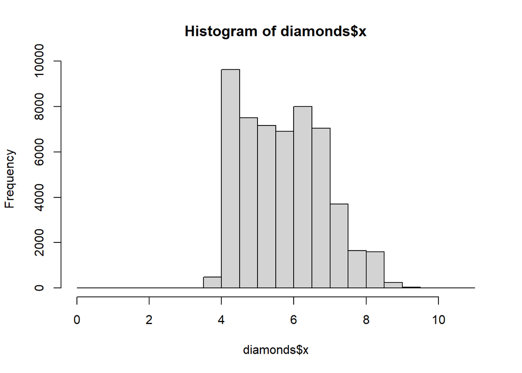

```r
hist(diamonds$x)
```

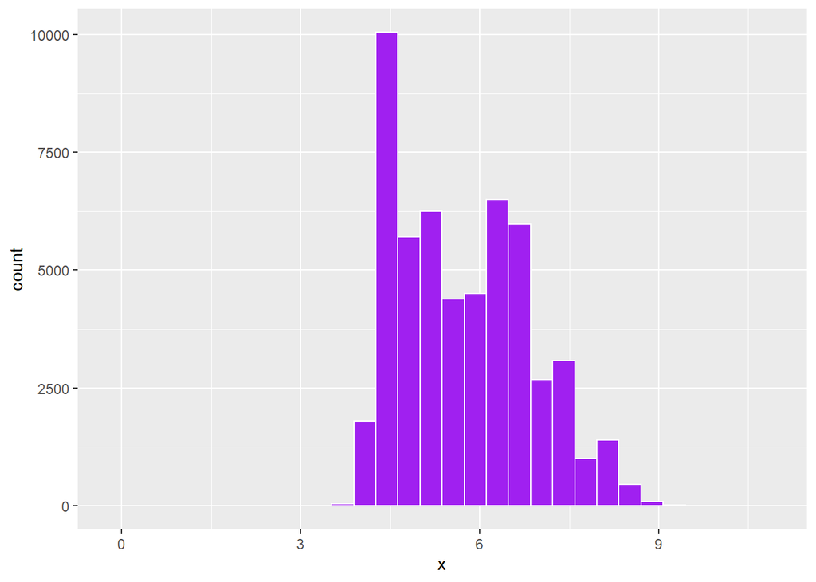

```r
ggplot(diamonds, aes(x = x)) + geom_histogram(bins=30, color = "white", fill = "purple")
```

### Análise: Acima fizemos a comparação da distribuição do comprimento (mm) dos diamantes conforme a faixa das quantidades, usando o histograma.

###Explorando a variável y, através do histograma.

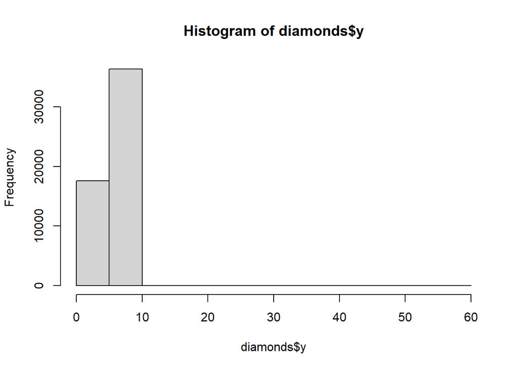

```r
hist(diamonds$y)
```

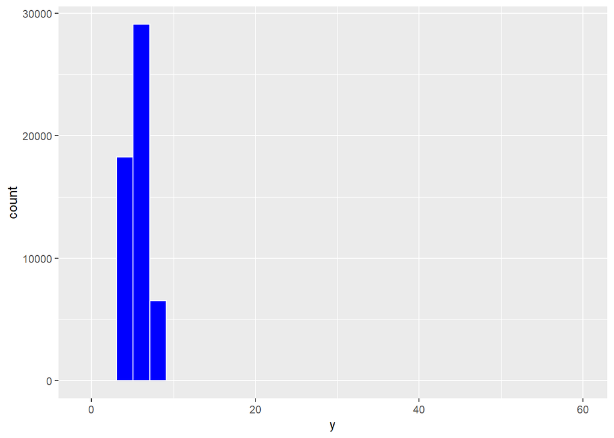

```r
ggplot(diamonds, aes(x = y)) + geom_histogram(bins=30, color = "white", fill = "blue")
```

### Análise: Acima fizemos a comparação da distribuição da largura (mm) dos diamantes conforme a faixa das quantidades, usando o histograma.

###Explorando a variável z, através do histograma.

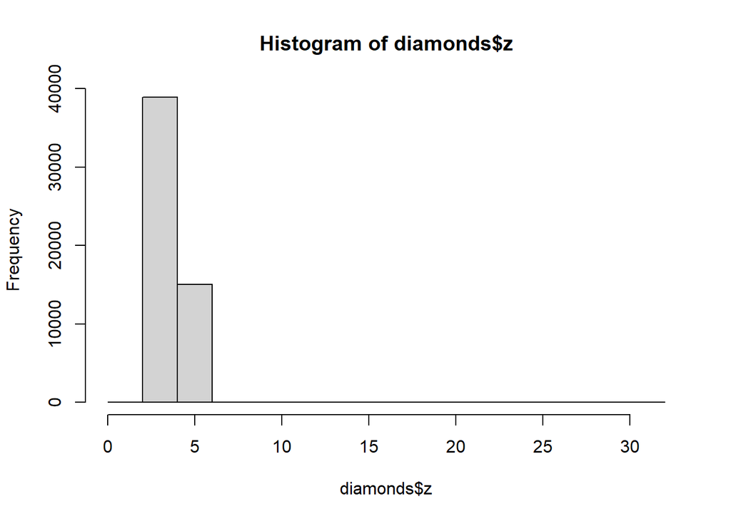

```r
hist(diamonds$z)
```

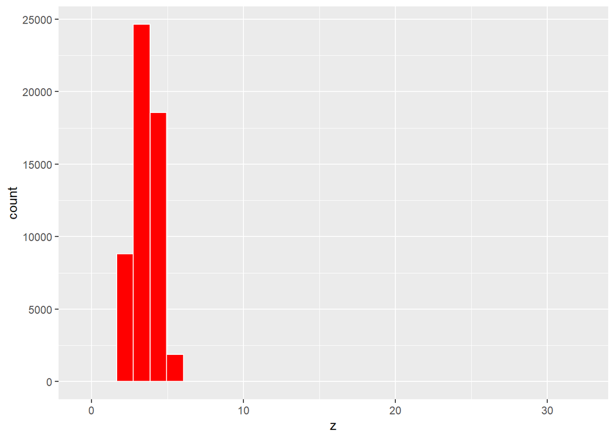

```r
ggplot(diamonds, aes(x = z)) + geom_histogram(bins = 30, color = "white", fill = "red")
```

### Análise: Acima fizemos a comparação da distribuição da profundidade (mm) dos diamantes conforme a faixa das quantidades, usando o histograma.

## Gráfico Boxplot

### Explore a variável price, seguindo o modelo de exploração.

Vamos analisar as variáveis de forma separada utilizando o gráfico Boxplot.

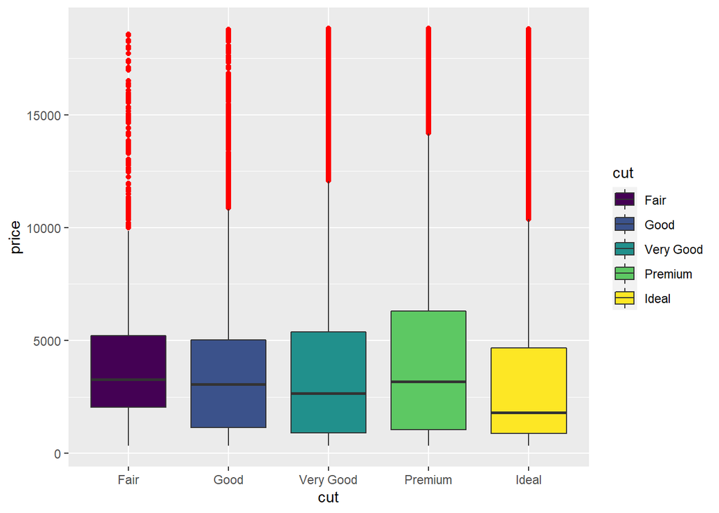

```r
#Boxplot para variáveis numéricas (devido a separação dos quartis)
ggplot(data = diamonds, mapping = aes(x = cut, y = price, fill =cut)) + geom_boxplot(outlier.color = "red")
```

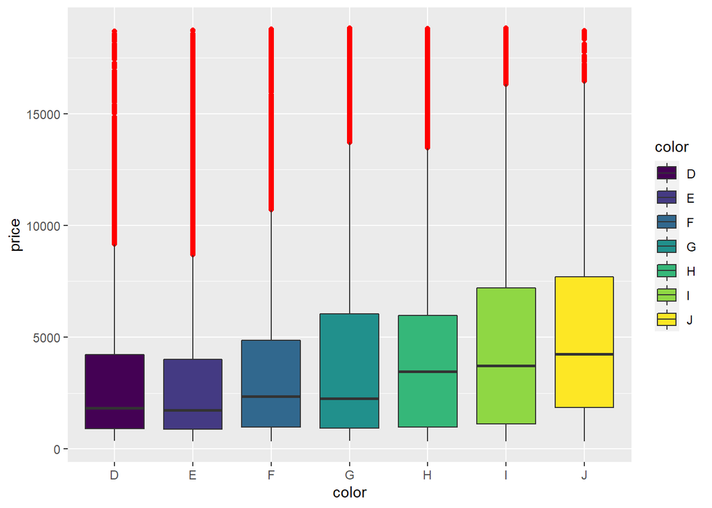

```r
#xlab("Qualidade do corte") + ylab("Preço(Dólares americanos)")
ggplot(data = diamonds, mapping = aes(x = color, y = price, fill =color)) + geom_boxplot(outlier.color = "red")
```

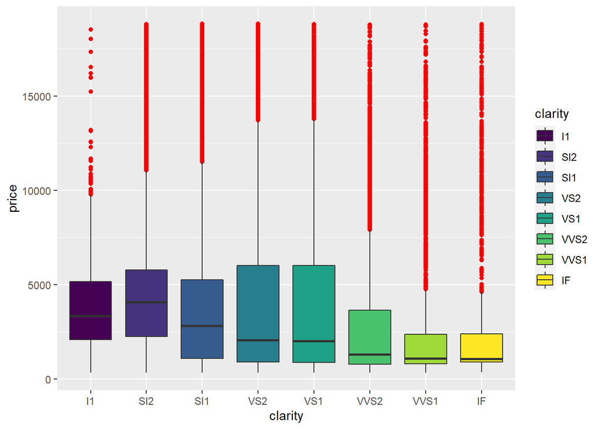

```r
#xlab("Cor") + ylab("Preço(Dólares americanos)")
ggplot(data = diamonds, mapping = aes(x = clarity, y = price, fill =clarity)) + geom_boxplot(outlier.color = "red")
```

```r
#xlab("Quão claro é o diamante") + ylab("Preço(Dólares americanos)")
```

### Explore a variável carat, seguindo o modelo de exploração.

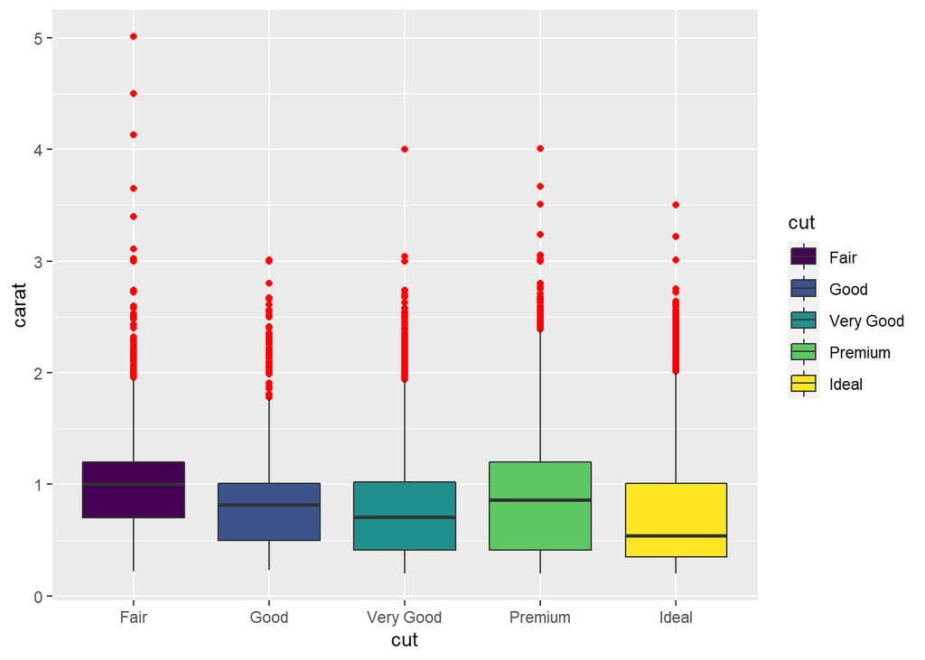

```r
ggplot(data = diamonds, mapping = aes(x = cut, y = carat, fill =cut )) + geom_boxplot(outlier.color = "red")
```

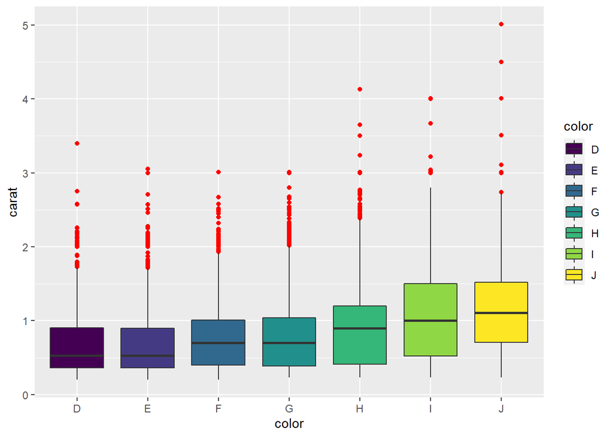

```r
ggplot(data = diamonds, mapping = aes(x = color, y = carat, fill =color )) + geom_boxplot(outlier.color = "red")
```

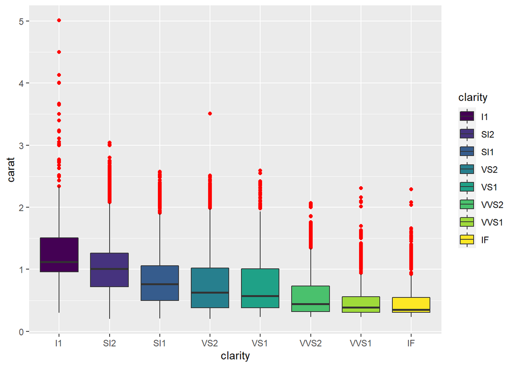

```r
ggplot(data = diamonds, mapping = aes(x = clarity, y = carat, fill =clarity )) + geom_boxplot(outlier.color = "red")
```

### Explore a variável depth, seguindo o modelo de exploração.

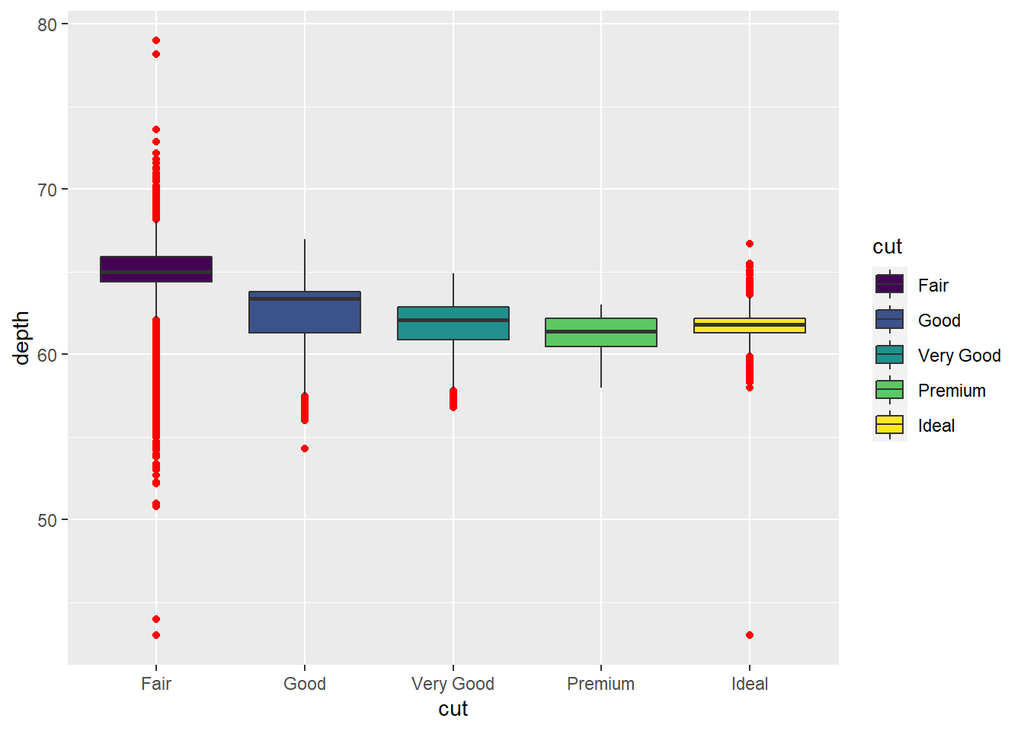

```r
ggplot(data = diamonds, mapping = aes(x = cut, y =depth , fill =cut )) + geom_boxplot(outlier.color = "red")
```

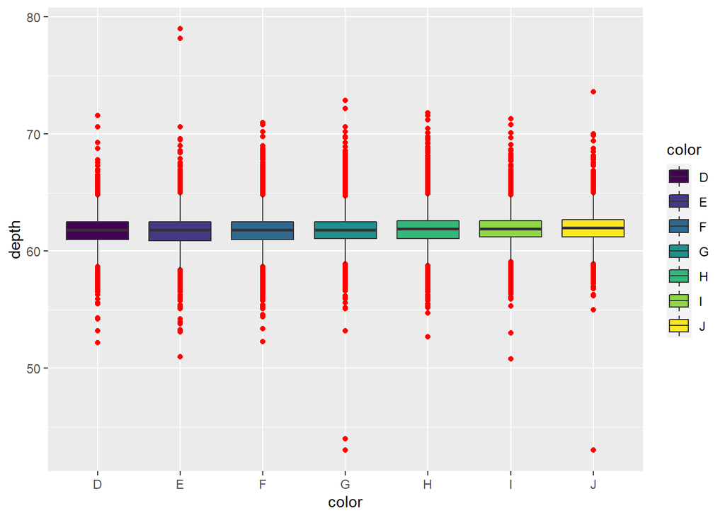

```r
ggplot(data = diamonds, mapping = aes(x = color, y =depth , fill =color )) + geom_boxplot(outlier.color = "red")
```

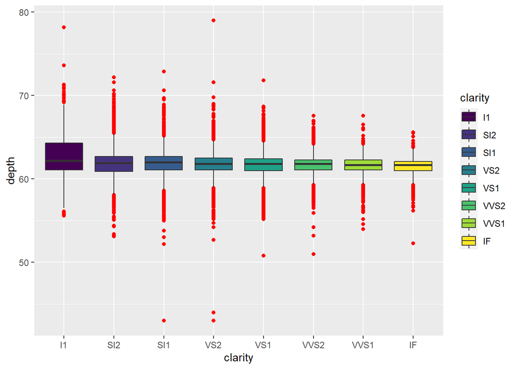

```r
ggplot(data = diamonds, mapping = aes(x = clarity, y =depth , fill =clarity )) + geom_boxplot(outlier.color = "red")
```

### Análise: Acima fizemos a comparação da porcentagem de profundidade dos diamantes conforme a qualidade do corte, cor e claridade (transparencia do diamante). O tipo de corte que mais influencia o a profundidade é o Fair. A qualidade de cor que mais influencia a profundidade E, G e J,pois apresentam valores outliers, embora todas sejam muito parecidos em sua mediana. A claridade (transparência) que mais influencia a profundidade é a I1, embora todas sejam muito parecidos em sua mediana.

### Explore a variável table, seguindo o modelo de exploração.

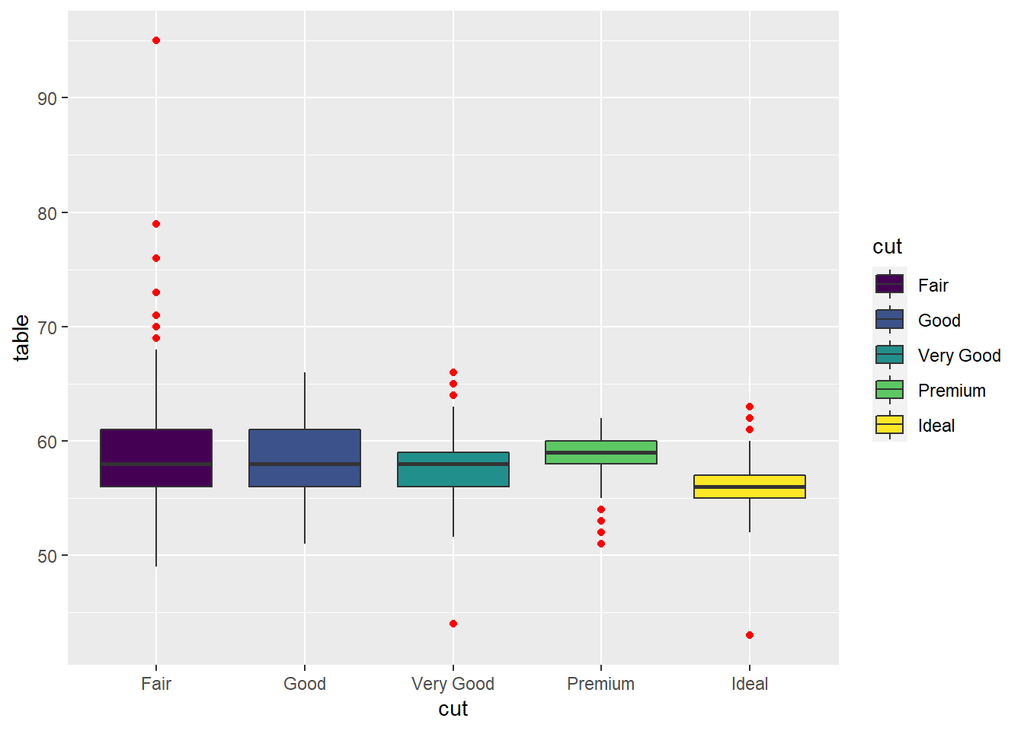

```r
ggplot(data = diamonds, mapping = aes(x = cut, y =table , fill =cut )) + geom_boxplot(outlier.color = "red")
```

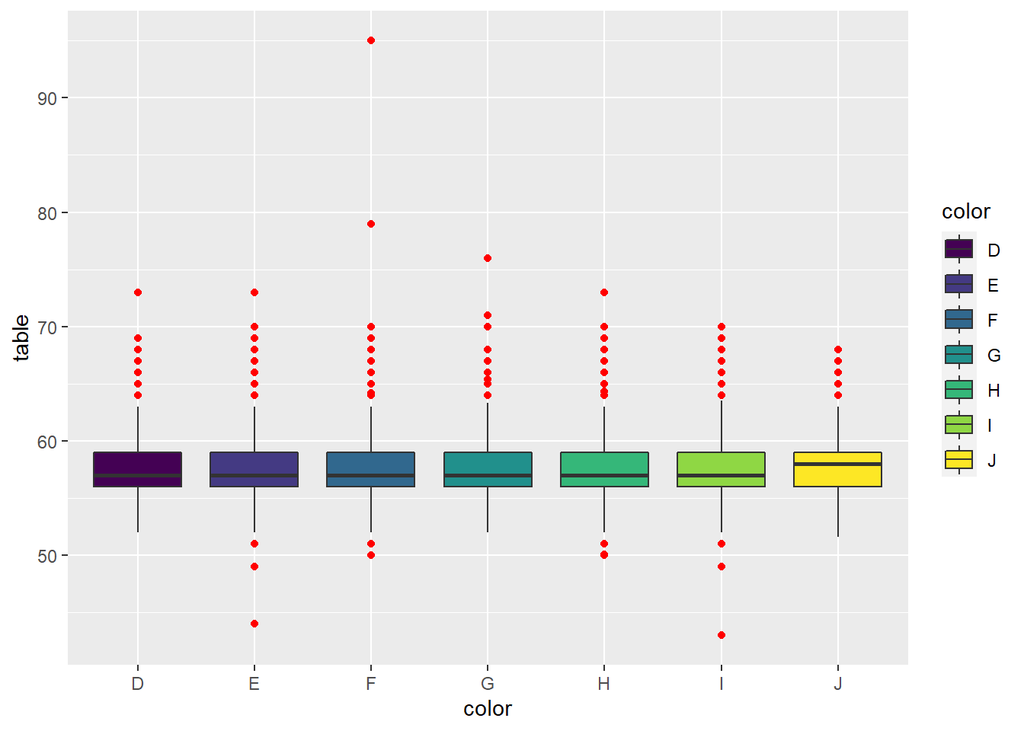

```r
ggplot(data = diamonds, mapping = aes(x = color, y =table , fill =color )) + geom_boxplot(outlier.color = "red")
```

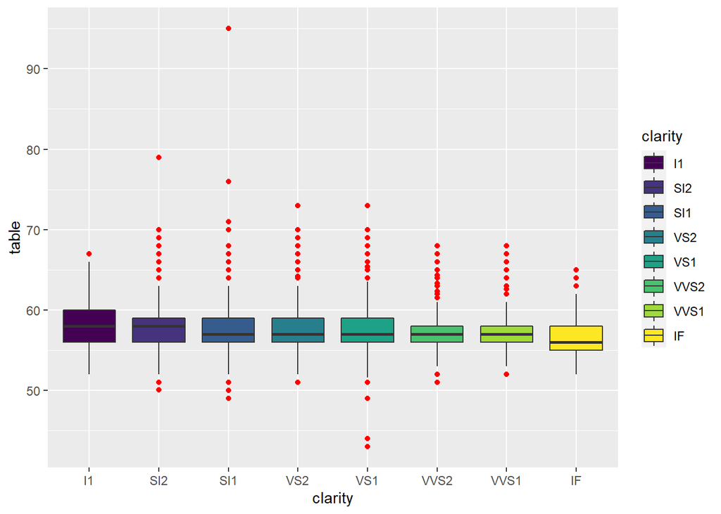

```r
ggplot(data = diamonds, mapping = aes(x = clarity, y =table , fill =clarity )) + geom_boxplot(outlier.color = "red")
```

### Análise: Acima fizemos a comparação da largura do topo do diamante relativo ao ponto mais largo dos diamantes conforme a qualidade do corte, cor e claridade (transparencia do diamante). O tipo de corte que mais influencia a largura do topo do diamante relativo ao ponto mais largo é o corte Fair, embora as medianas sejam muito próximas. A qualidade de cor que mais influencia a largura do topo do diamante relativo ao ponto mais largo é a cor F, embora as medianas sejam muito próximas. A claridade (transparência) que mais influencia largura do topo do diamante relativo ao ponto mais largo é a transparência SI1, embora as medianas sejam muito próximas.

### Explore a variável z, seguindo o modelo de exploração.

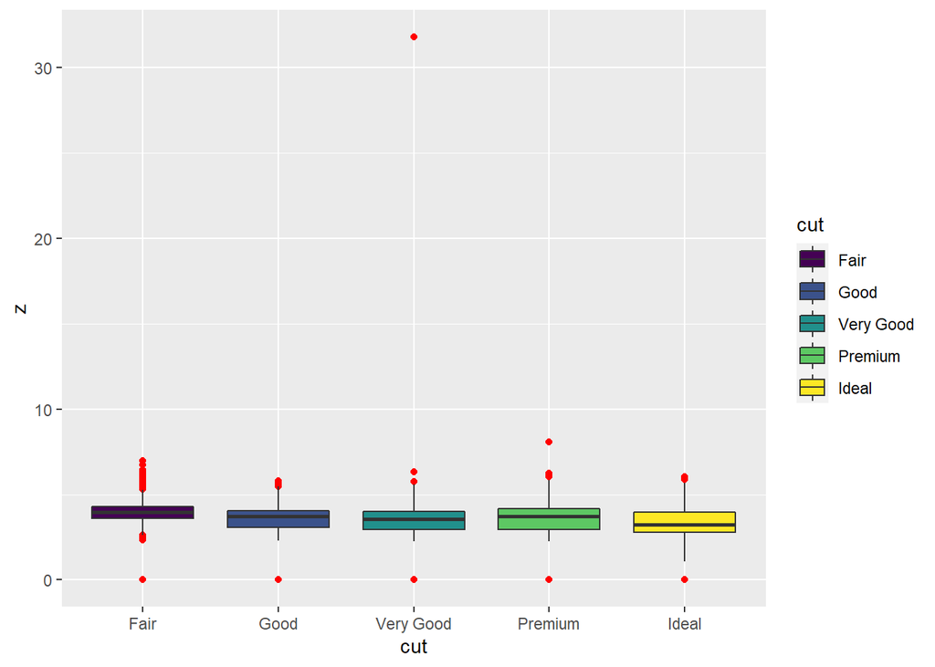

```r
ggplot(data = diamonds, mapping = aes(x = cut, y =z , fill =cut )) + geom_boxplot(outlier.color = "red")
```

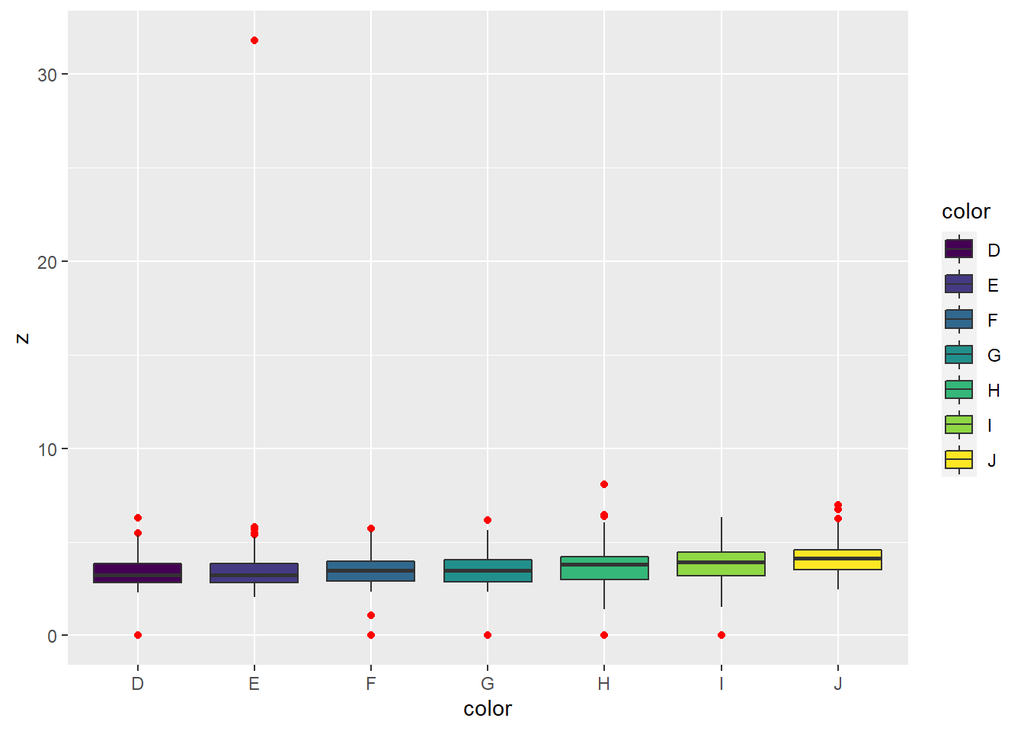

```r
ggplot(data = diamonds, mapping = aes(x = color, y =z , fill =color )) + geom_boxplot(outlier.color = "red")
```

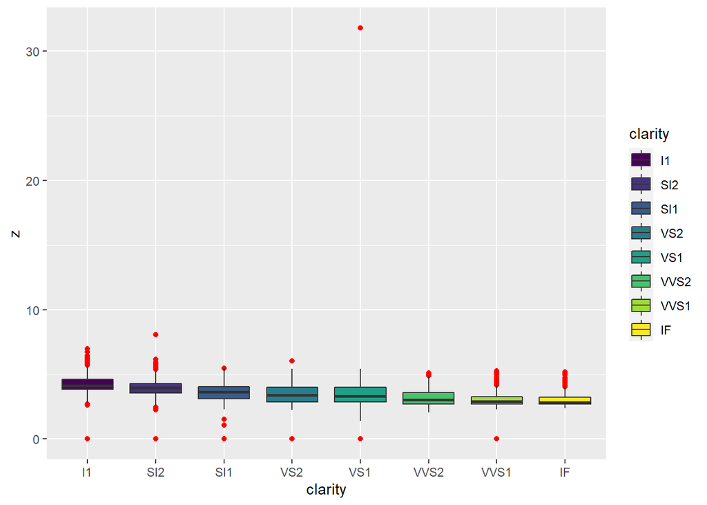

```r
ggplot(data = diamonds, mapping = aes(x = clarity, y =z , fill =clarity )) + geom_boxplot(outlier.color = "red")
```